# Reto 4. Reduciendo la brecha de acceso a Internet en población de escasos recursos

## Contexto

Buenaventura es una ciudad en la que el acceso a una infraestructura de comunicación digital viene rezagada en comparación con otras ciudades del país. Según el Ministerio de Tecnologías de la Información y las Comunicaciones, en el año 2020, el 56% de la población en Buenaventura no contaba con acceso a Internet. Esto revela una brecha digital que afecta a la población más vulnerable, que no tiene acceso a servicios de educación, salud, empleo y entretenimiento en línea. Por ello es necesario dedicar esfuerzos para introducir infraestructuras de conectividad que permitan cerrar esta brecha digital. Dadas las condiciones geográficas de Buenaventura, cualquier intento de llevar conectividad a la ciudad debe considerar el hecho de que los recursos económicos son limitados y por lo tanto no siempre es posible contar con conectividad inalámbrica de alta velocidad en todos los puntos de acceso. La instalación de cableado se hace indispensable, y con frecuencia atravesando secciones marinas. En este reto se te plantea la construcción de un modelo que describa el gasto del material de cableado (medido en términos de diámetro actual) en función del tiempo de permanencia bajo el agua.

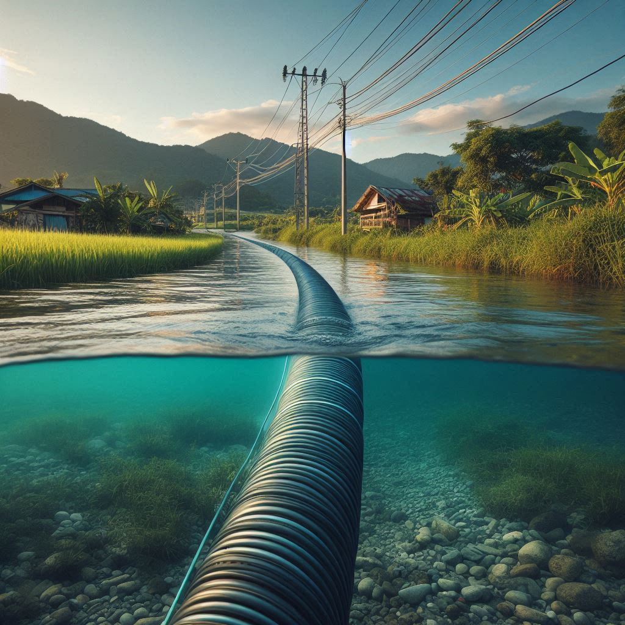

## Objetivos

### Objetivo general

Diseñar e implementar computacionalmente un modelo matemático que permita estimar el desgaste de material de un cable submarino (con respecto al tamaño del diámetro del cable) en función del tiempo de permanencia en el agua.

### Objetivos específicos

- Utilizar herramientas de Python para la visualización de datos, en particular para observar y analizar el cambio de una variable con respecto a otra.
- Identificar el concepto de función en términos de términos de transformación de una variable en otra (modelo entrada-salida)
- Determinar las propiedades específicas de una función lineal (pendiente, punto de corte, dominio, rango, etc.)
- Determinar las propiedades específicas de una función cuadrática (vértice, eje de simetría, dominio, rango, etc.)

## Contenido de apoyo

### Visualización de datos en Python

En Python es posible visualizar datos de manera sencilla utilizando la librería `matplotlib`. La construcción de gráficos en Python corresponde a la misma idea de construir gráficos en papel, es decir, se debe definir un sistema de coordenadas y luego ubicar los puntos que se desean graficar. En el siguiente ejemplo se muestra una representación gráfica del plano cartesiano en Python.

```python
import matplotlib.pyplot as plt
import numpy as np

# Crear una figura y un conjunto de subtramas
fig, ax = plt.subplots()

# Dibujar los ejes
ax.axhline(0, color='black',linewidth=0.5)
ax.axvline(0, color='black',linewidth=0.5)

# Configurar los límites de los ejes
ax.set_xlim([-10, 10])
ax.set_ylim([-10, 10])

# Etiquetar los ejes
ax.set_xlabel("Eje X")
ax.set_ylabel("Eje Y")

# Etiquetar las regiones del plano cartesiano
plt.text(5, 5, 'I', fontsize=12)
plt.text(-5, 5, 'II', fontsize=12)
plt.text(-5, -5, 'III', fontsize=12)
plt.text(5, -5, 'IV', fontsize=12)

# Mostrar la gráfica
plt.show()
```

[figure not shown]

Los dos primeras líneas de código son instrucciones de importación en Python. Están importando dos bibliotecas muy utilizadas en el análisis de datos y la visualización: matplotlib.pyplot y numpy.

La primera línea, import matplotlib.pyplot as plt, importa el módulo pyplot de la biblioteca matplotlib. matplotlib es una biblioteca para la creación de gráficos estáticos, animados e interactivos en Python. pyplot es un módulo de matplotlib que permite controlar muchas características de las gráficas. El as plt es un alias, lo que significa que en lugar de tener que escribir matplotlib.pyplot cada vez que quieras usar una función de este módulo, puedes escribir simplemente plt.

La segunda línea, import numpy as np, importa la biblioteca numpy. numpy es una biblioteca para trabajar con números de todo tipo, y proporciona una gran cantidad de funciones matemáticas útiles. Al igual que con matplotlib.pyplot, se utiliza un alias para simplificar el código, por lo que puedes usar np en lugar de numpy para acceder a las funciones y características de numpy.

Estas dos bibliotecas son fundamentales en el análisis y la visualización de datos en Python, y es muy común verlas importadas juntas al inicio de los scripts de Python en este campo.

La línea de código fig, ax = plt.subplots() es una forma común de iniciar una figura y un conjunto de ejes en Matplotlib, una biblioteca de visualización de datos en Python.

plt.subplots() es una función que devuelve una tupla que contiene una figura y ejes. Aquí, fig y ax son simplemente las variables a las que se asignan la figura y los ejes, respectivamente. Puedes pensar en la “figura” como el contenedor que contiene los “ejes” (donde se dibujan los gráficos).

Por defecto, plt.subplots() crea una figura con un solo gráfico. Si necesitas más gráficos en la misma figura, puedes especificar el número de filas y columnas como argumentos. Por ejemplo, plt.subplots(2, 2) crearía una figura con 4 gráficos, dispuestos en 2 filas y 2 columnas.

Una vez que tienes la figura y los ejes, puedes empezar a dibujar en ellos usando métodos como ax.plot(), ax.scatter(), etc. También puedes ajustar las propiedades de la figura y los ejes, como los títulos, las etiquetas de los ejes, los límites de los ejes, y más.

En el resto del código , se dibujan los ejes horizontal y vertical de la gráfica con las funciones axhline y axvline. Ambas líneas se dibujan en la posición 0 (el origen) y se configuran con un color negro y un grosor de 0.5.

Luego, se establecen los límites de los ejes X e Y con las funciones set_xlim y set_ylim. Ambos ejes se configuran para tener un rango de -10 a 10.

Después, se etiquetan los ejes X e Y con las funciones set_xlabel y set_ylabel. Estas etiquetas ayudan a identificar los ejes en la gráfica.

A continuación, se etiquetan las cuatro regiones del plano cartesiano con la función text. Esta función coloca un texto en las coordenadas especificadas. En este caso, se están etiquetando las cuatro cuadrantes del plano cartesiano con los números romanos I, II, III y IV.

Finalmente, se muestra la gráfica con la función show. Esta función abre una ventana con la gráfica generada.

Supon que queremos graficar la recta que une los puntos (2,3) y (-1.7). El siguiente código realiza esta tarea

```python
import matplotlib.pyplot as plt

x = [2, -1] # Observa que se listan los valores de la primera coordenada en cada punto dad
y = [3, 7] # Observa que se listan los valores de la segunda coordenada en cada punto dado

plt.plot(x, y)
plt.text(x[0], y[0], f'($x_1$,$y_1$)=({x[0]},{y[0]})', fontsize=12, ha='right')
plt.text(x[1], y[1], f'($x_2$,$y_2$)=({x[1]},{y[1]})', fontsize=12, ha='left')
plt.title('Gráfica de la recta que une los puntos ($x_1$,$y_1$) y ($x_2$,$y_2$)')
plt.xlabel('x')
plt.ylabel('y')
plt.grid(True)
plt.show()
```

[figure not shown]

Como se ha visto ya en módulos anteriores, es posible usar Python para calcular propiedades o características específicas, por ejemplo, la distancia entre los puntos (2,3) y (-1,7)

```python
import math

# Definir los puntos
punto1 = (2, 3)
punto2 = (-1, 7)

# Calcular la distancia
distancia = math.sqrt((punto2[0] - punto1[0])**2 + (punto2[1] - punto1[1])**2)

print("La distancia entre los puntos es:", distancia)
```

```
La distancia entre los puntos es: 5.0
```

Para el cálculo de la distancia ,primero, se resta la coordenada $x$ del primer punto (punto1[0]) de la coordenada $x$ del segundo punto (punto2[0]). Luego, se eleva al cuadrado el resultado de esta resta. Se realiza la misma operación para las coordenadas $y$ de los puntos.

Después, se suman estos dos resultados y finalmente se aplica la función math.sqrt para obtener la raíz cuadrada de esta suma. El resultado es la distancia entre punto1 y punto2.

Podríamos obtener también la pendiente de la recta que une los puntos (2,3) y (-1,7) con la fórmula: $m = \dfrac{y_2 - y_1}{x_2 - x_1}$

```python
# Definir los puntos
punto1 = (2, 3)
punto2 = (-1, 7)

# Calcular la pendiente
pendiente = (punto2[1] - punto1[1]) / (punto2[0] - punto1[0])

print("La pendiente de la recta es:", pendiente)
```

```
La pendiente de la recta es: -1.3333333333333333
```

Con estas herramientas es posible observar el comportamiento de una variable con respecto a otra, y realizar cálculos específicos para obtener información relevante de los datos. La siguiente celda visualiza el comportamiento de un conjunto de puntos en el plano

```python
import matplotlib.pyplot as plt

# Datos de ejemplo
x = [1, 2, 3, 4, 5]
y = [2, 3, 5, 7, 11]

# Crear la gráfica
plt.figure(figsize=(8, 6))
plt.plot(x, y, 'o-')  # 'o-' significa que los puntos están conectados por líneas

# Etiquetas de los ejes
plt.xlabel('Eje X')
plt.ylabel('Eje Y')

# Título de la gráfica
plt.title('Gráfica de Y vs X')

# Mostrar la gráfica
plt.show()
```

[figure not shown]

Observa ahora un ejemplo, en donde también se grafican datos en $Y$ contra datos en $X$

```python
import matplotlib.pyplot as plt

# Datos de ejemplo
x = [1, 2, 2, 3, 4, 4, 4, 5]
y = [2, 3, 4, 5, 7, 8, 9, 11]

# Crear la gráfica
plt.figure(figsize=(8, 6))
plt.scatter(x, y)  # 'scatter' crea una gráfica de dispersión

# Etiquetas de los ejes
plt.xlabel('Eje X')
plt.ylabel('Eje Y')

# Título de la gráfica
plt.title('Gráfica de Y vs X')

# Mostrar la gráfica
plt.show()
```

[figure not shown]

Podrías indicar cual de las dos gráficas anteriores corresponde a una función y cual no?

Graficar funciones en python es muy sencillo, por ejemplo, para graficar la función $f(x) = \dfrac{4}{3}x-\dfrac{1}{3}$ en el intervalo $[-10,10]$ se puede usar el siguiente código

```python
import matplotlib.pyplot as plt
import numpy as np

# Genera los valores de x
x = np.linspace(-10, 10, 400)

# Define la ecuación de la recta
y = (4/3)*x - (1/3)

# Crea el gráfico
plt.plot(x, y)

# Establece los límites del gráfico
plt.xlim(-10, 10)
plt.ylim(-10, 10)

# Muestra el gráfico
plt.show()
```

[figure not shown]

La función linspace está generando una secuencia de 400 números que van desde -10 hasta 10 (ambos inclusive). Los números generados están igualmente espaciados en este rango.

El primer argumento de la función linspace es el valor inicial del intervalo, que en este caso es -10. El segundo argumento es el valor final del intervalo, que en este caso es 10. El tercer argumento es el número de muestras que se generarán, que en este caso es 400.

El resultado de esta función se almacena en la variable x. Así que después de ejecutar esta línea de código, x será una lista que contiene 400 números igualmente espaciados desde -10 hasta 10.

### Graficando funciones lineales

Combinando las herramientas presentadas anteriormente, es posible graficar la recta que une dos puntos en el plano cartesiano, para cualquier par de puntos dados , es decir, dados $(x_1,y_1)$ y $(x_2,y_2)$, queremos obtener la recta que pasa por estos dos puntos con la ecuación $y = mx + b$, donde $m$ es la pendiente de la recta y $b$ es la ordenada al origen.

```python
import libreria4 as li
# Definir los puntos
punto1 = (2, 3)
punto2 = (-1, 7)

# Llamar a la función para graficar la recta
li.grafica_recta(punto1, punto2)
```

[figure not shown]

Ahora bien, si usamos la forma punto pendiente , es decir $y-y_0=m(x-x_0)$, donde $(x_0,y_0)$ es un punto en la recta, podemos graficar la recta correspondiente la pendiente dada $m$ y el punto dado $(x_0,y_0)$

```python
import libreria4 as li

# Definir la pendiente y el punto
pendiente = -4/3
punto = (2, 3)

# Llamar a la función para graficar la recta
li.grafica_recta_pendiente_punto(pendiente, punto)
```

[figure not shown]

Dadas dos rectas $y = m_1x + b_1$ y $y = m_2x + b_2$, es posible graficarlas en un mismo plano cartesiano, para ello se puede usar el siguiente código

```python
import libreria4 as li
# Definir las pendientes y los puntos
pendiente1 = 2
punto1 = (1, 3)

pendiente2 = -1/2

punto2 = (2, -2)

# Llamar a la función para graficar ambas rectas
li.grafica_dos_rectas(pendiente1, punto1, pendiente2, punto2)
```

[figure not shown]

### Graficando funciones cuadráticas

Así como fue posible graficar funciones lineales, es posible realizar la misma tarea para el caso de funciones cuadráticas. Recuerda que na función cuadrática tiene la forma $f(x) = ax^2 + bx + c$, donde $a$, $b$ y $c$ son constantes. Usaremos la función cuadrática para exhibir otra alternativa a la graficación de funciones en Python que vincula el paquete SymPy que has usado en módulos anteriores

```python
import sympy as sp
from sympy.plotting import plot

# Definir la variable
x = sp.symbols('x')

# Definir la función cuadrática, por ejemplo: f(x) = x^2 + 2x + 1
f = x**2 + 2*x + 1

# Graficar la función
p = plot(x**2, show=False)
p.show()
#
```

[figure not shown]

En el caso de querer usar Matplotlib para graficar la función cuadrática, se puede usar el siguiente código:

```python
import numpy as np
import matplotlib.pyplot as plt

# Generar valores de x
x = np.linspace(-10, 10, 400)

# Evaluar la función cuadrática directamente
y = x**2 + 2*x + 1

# Graficar
plt.plot(x, y, label='$f(x) = x^2 + 2x + 1$')
plt.xlabel('x')
plt.ylabel('f(x)')
plt.title('Gráfica de la función cuadrática')
plt.legend()
plt.grid(True)
plt.show()
```

[figure not shown]

Como en el caso de una función lineal, en la que basta con dos puntos , o la pendiente y un punto para trazar la recta, en el caso de una función cuadrática, basta con tres puntos (siempre y cuando estos puntos no estén sobre una misma recta) o el coeficiente principal y un punto para trazar la parábola. En el siguiente código se muestra como graficar una parábola dados 3 puntos.

```python
import libreria as li
# Definir los tres puntos
punto1 = (-1, 2)
punto2 = (2, 3)
punto3 = (3, 5)

# Llamar a la función para graficar la parábola
li.grafica_parabola(punto1, punto2, punto3)
```

[figure not shown]

Si se quiere graficar una parábola en forma canónica (es decir, en la forma $f(x) = a(x-h)^2 + k$), se puede usar el siguiente código

```python
import libreria as li

coef_principal = -1
h=2
k=3
# Llamar a la función para graficar la parábola
li.grafica_parabola_can(coef_principal, h, k)
```

[figure not shown]

En las siguientes dos celdas puedes ajustar los valores de $a$, $h$ y $k$ para observar como cambia la gráfica de la parábola en el caso de la forma canónica y también los valores de $a$, $b$ y $c$ para observar como cambia la gráfica de la parábola en el caso de la forma general.

```python
import libreria as li
from IPython.display import display
import ipywidgets as widgets

# Crear un widget interactivo para la gráfica
parabola_widget = widgets.interactive(li.update_grafica, a=li.a_slider, h=li.h_slider, k=li.k_slider)

# Mostrar el widget
display(parabola_widget)
```

```python
import libreria as li
from IPython.display import display
import ipywidgets as widgets

# Crear un widget interactivo para la gráfica
cuadratica_widget = widgets.interactive(li.update_grafica_cuad, a=li.a_slider, b=li.b_slider, c=li.c_slider)

# Mostrar el widget
display(cuadratica_widget)
```

## Apropiación y aplicación del contenido

1. Determine la ecuación de la recta que pasa por el punto $(4,-2)$ y es perpendicular a la recta $4x-2y+3=0$.
2. Encuentre la ecuación de la recta que pasa por el punto $(2,3)$ y es paralela a la recta $3x-2y+1=0$.
3. Determine la ecuación de la recta que pasa por los puntos $(1,2)$ y $(3,4)$.
4. Escriba la ecuación de la parábola que tiene vértice en el punto $(1,2)$ y pasa por el punto $(3,4)$.
5. Reescriba la ecuación de la parábola $y = 2x^2 + 4x + 1$ en la forma canónica.
6. Determine el vértice de la parábola $y = 2x^2 + 4x + 1$.
7. Grafique las rectas y parábolas obtenidas en los ejercicios anteriores.

## Familiaridad con el reto

Una pieza rectangular de metal está recubierta con un material protector que se desgasta linealmente con el tiempo debido a la fricción. La pieza tiene una longitud de $L$ metros y un ancho de $W$ metros. Inicialmente, el grosor del material protector es de $T_0$ milímetros. Después de $t$ meses, el grosor del material protector es de $T$ milímetros.

Se sabe que el material protector se desgasta a una tasa constante de $r$ milímetros por mes.

1. Si $T(t)$ representa el grosor del material protector en milímetros después de $t$ meses, determine $T(t)$ en función de $t$ como una función lineal.

**Respuesta.** Si $T_0$ es el grosor inicial del material protector, entonces después de $t$ meses, el grosor del material protector es de $T_0 - rt$ milímetros. Por lo tanto, la función lineal que representa el grosor del material protector en función del tiempo es $T(t) = T_0 - rt$.

2. Determine el tiempo de desgaste del material protector.
3. Determinar el área total de la superficie expuesta de la pieza de metal después de $t$ meses. (Tener en cuenta la fracción de la superficie que se desgasta con respecto al grosor inicial $T_0$)
4. Graficar la función $T(t)$ y determine si la variación del grosor del material protector con respecto al tiempo es positiva o negativa..
5. Si la función $T(t)$ es ahora de la forma $T(t)=1-2t+4t^2, determine el tiempo en que el grosor del material protector es de 1 mm.
6. Considerando el punto 5, determine el tiempo en que el grosor del material protector llega a su groso más pequeño. Grafique y compare su solución con el punto 4.